# Student Performance in Math Courses

Group 15 - Marissa Ashner, Ben Bulen, Kyle Grosser, Benjana Guraziu, Kushal Shah

4/29/2019

## Introduction

Portugal, in 2006, had an early school leaving rate of nearly 40% for 18-24 year olds, while the EU average was 15% (Eurostat 2007). Various analyses and interventions, therefore, have targeted school success in Portuguese adolescents and have attempted to improve overall education. Portuguese students are lacking in mathematics performance, specifically, compared to students in surrounding countries.

We are therefore analyzing student data from two Portuguese secondary schools. This dataset measures mathematics course grade as the outcome, as a result of 30 predictors that range from demographic factors and family situation to student habits and extracurricular involvement. Specifically, data was collected from 395 students across an age range of 15-22 years (Cortez & Silva 2008).

Portuguese schools have a five-level grade classification system. With a final score measured from 0-20, categories are as follows: Excellent (16-20), Good (14-15), Satisfactory (12-13), Sufficient (10-11), Fail (0-9). For the purposes of this analysis, however, we analyzed exact score rather than score category.

In this analysis, we wish to predict student success in secondary school math as a result of two types of factors:

1. Unchangeable (family situation, parents’ jobs, home location, etc.)
2. Targetable behavior (alcohol consumption, absences, extracurricular involvement, etc.)

The potential outcomes of this analysis are:

1. Indentification of inherent factors present in certain students’ backgrounds that may put them at a disadvantage to begin with. Early identification without discrimination could result in these students being helped more effectively along the way.
2. Identification of student behaviors that can be targeted through school-related programs or interventions in order to increase success

## Data Description

There are 30 inital covariates in the dataset. They are listed below and are described further in the Appendix.

- Covariates: School, Sex, Age, Address, Famsize, Pstatus, Medu, Fedu, Mjob, Fjob, Reason, Guardian, Traveltime, Studytime, Failures, Schoolsup, Famsup, Paid, Activities, Nursery, Higher, Internet, Romantic, Famrel, Freetime, Goout, Dalc, Walc, Health, Absences
- Response Variables: G1 (first period grade), G2 (second period grade), and G3 (final grade)

All the responses are numeric variables that range from 0 to 20. For this analysis, we will be considering the `G3` final grade as the output target. The reason for this is that all three response variables are very highly correlated, which can be seen visually in Figure 1 of the Appendix.

## Expoloratory Data Analysis and Variable Filtering

We looked at the distribution of the outcome variable, final grade, and noticed that the distribution was fairly normal except for a large number of 0’s (see Figure 2 in the Appendix). Looking further, all of these students had positive grades for the first and second periods, so it didn’t seem to make practical sense that their final grades were zero. Since we were not given more information on what these zeros meant, whether it was for students moving, dropping out, or missing values, we decided to drop the values from the data for our purposes.

We additionally had to perform some scaling of predictors in order to avoid problems of collinearity with these variables and the intercept. The first of these variables was the `absences` variable. While most of our variables were factors or numeric variables with small ranges, `absence` ranged from 0 to 93 and was very skewed right. We decided to bin the absence variable into a 5-level numeric variable where 1 is absences less than 5, 2 is absences between 5 and 10, and so on for 3 and 4, with 5 corresponding to absences greater than 20. The distribution before and after this variable transformation is shown in the plots below.

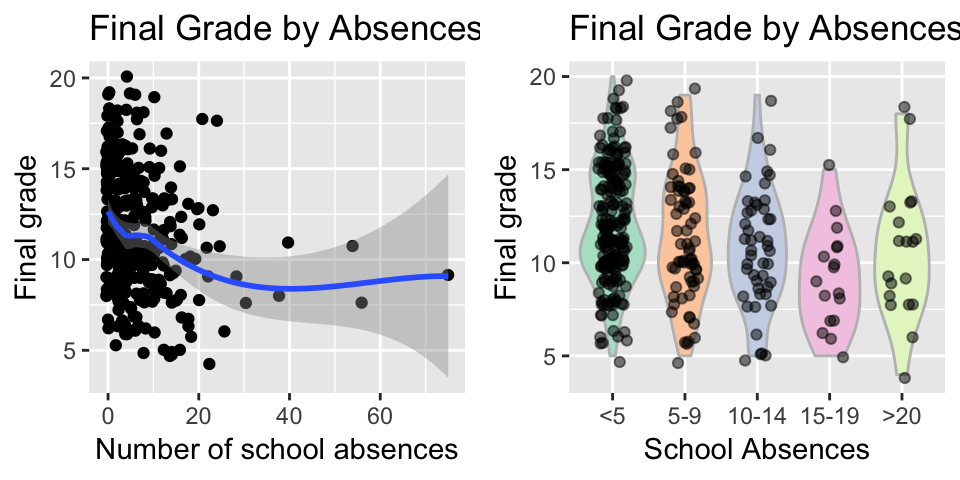

The second variable we transformed was the `age` variable. We subtracted each age from the minimum age so the range was changed from 15-22 to 0-7.

Based on some exploratory data an analysis plots (see Figure 3 in the Appendix), we decided to remove the variable `guardian` from our dataset since it didn’t seem to have any influence on the outcome. We also observed that students in this dataset were from two different schools. Using `school` in our prediction of math course success, although it may increase prediction accuracy, would make our analysis less generalizable to the overall population of students. Since the overarching goal of this analysis is to identify factors that systematically affect secondary school student success in math courses, we decided to remove `school` as a predictor variable.

### Collinearity Analysis

Before running any models on our data, we want to check some computational diagnostics to see whether or not the covariates are collinear with each other or the intercept. To do that, we can first calculate the VIF and Tolerance values for each covariate.

We then conduct an eigen-analysis of the correlation and scaled SSCP matrices to determine which covariates are most collinear with each other (via the correlation matrix) and with the intercept (via the scaled SSCP matrix).

From the Correlation Matrix, the highest Condition Index is still very small, which means no collinearity needs to be taken care of there. From the Scaled SSCP Matrix, there is one Condition Index over 30.

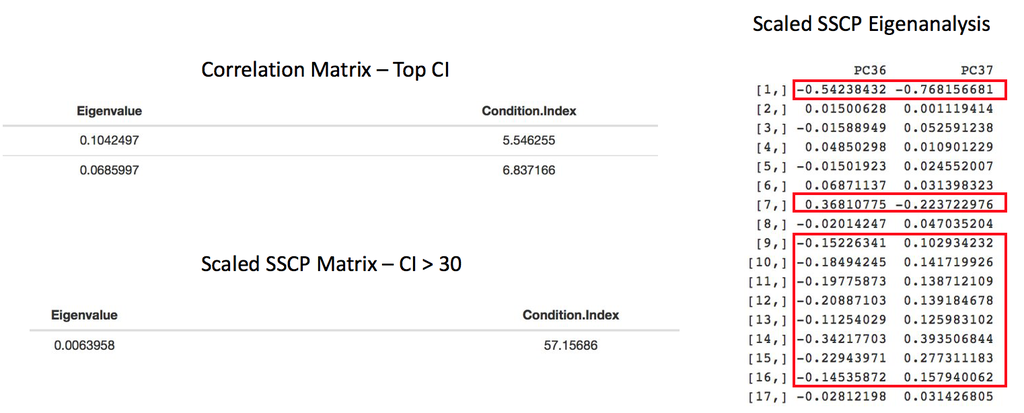

Above shows the last 2 PC’s of the Scaled SSCP Matrix for the 1st-17th covariates (the rest have values close to 0). We can see that the 7th and 9-16th covariates may be collinear with the intercept. These covariates are listed below.

```
## [1] "Medu"         "Mjobhealth"   "Mjobother"    "Mjobservices"
## [5] "Mjobteacher"  "Fjobhealth"   "Fjobother"    "Fjobservices"
## [9] "Fjobteacher"
```

After transforming `absences` and `age` as described in the previous section, the only variables that remain collinear with the intercept are factor variables. Since we coded our design matrix using reference cell coding, the collinearity of these variables with the intercept is somewhat expected since they have reference values in the intercept. Therefore we decided not to remove any variables from our full model.

### HILE Gauss Assumptions

The homogeneity of variances, linearity, and gaussian errors asssumptions usually go hand in hand, and can be tested for each model using a residual analysis. For each model we run, we conduct an Anderson-Darling Test for Normality (see Figure 4 in the Appendix), and create residual plots (see Figure 5 in the Appendix). For all models in this report, all three of these diagnostics were met. In terms of the existence assumption, we assume it holds since we have a finite sample. We also must assume the independence of observations assumption holds for our analysis, although we do not have enough information to fully support this claim. We are not given information on the students such as whether or not there are siblings or related students in the group, whether or not certain study groups were relevant, whether or not the classes were curved, or other qualities of the data that could result in a violation of this assumption. Therefore we move forward claiming all assumptions are satisified.

## Models and Model Testing

There are many types of models to consider when building a regression classifier, such as Multiple Linear Regression, ANOVA, Linear Mixed Models, and Logistic/Poisson Regression. Classically, Linear Mixed Models are used when observations are related and Logistic/Poisson Regression are used for binary outcomes. Since we are assuming our observations (the students) are independent and the outcome variable (final grade) is numeric, we narrow our model search down to Multiple Linear Regression and ANOVA. Since, at the beginning, we have many factor-type covariates, we begin exploring Multiple Linear Regression models and their fit to our data.

### Model 1: Full Model

The first model we consider is a full model of all covariates possible and no interaction terms included. The model can be written as follows:

$$y = \beta_0 + \beta_1X_1 + ... + \beta_{36}X_{36} + \epsilon$$

It should be noted that the adjusted $R^2$ value for this model is 0.2542165.

### Model 2: No Intercept

Since, from the collinearity analysis, several variables were significantly collinear with the intercept, we next try to build a model identical to the full model with the removal of the intercept to see how that affects the results of the model. It can be written as follows:

$$y = \beta_1X_1 + ... + \beta_{36}X_{36} + \epsilon$$

It should be noted that the adjusted $R^2$ value for this model is 0.9370466. Although this model is nested in the full model, the adjusted $R^2$ is much larger than that of the full model, which is not expected. This is misleading, as models without an intercept should not necessarily be used to model data, even if they appear to explain more of the variation between your observations.

### Model 3: Stepwise Model

We then employed forward selection, backward selection, and combined forward and backward selection using the `step` function in R, which selects a model based on AIC. Forward selection alone gives the full model, while backward selection and combined selection yield the same 13 covariates. We adopted the result of backward selection as our third model. The covariates chosen are as follows:

$$y = \beta_0 + \beta_1SEXM + \beta_2AGE + \beta_3ADDRESSU + \beta_4MJOBHEALTH + \beta_5MJOBSERVICES + \beta_6FJOBTEACHER + \beta_7STUDYTIME + \beta_8FAILURES + \\ \beta_9SCHOOLSUPYES + \beta_{10}FAMSUPYES + \beta_{11}GOOUT + \beta_{12}HEALTH + \beta_{13}ABSENCES + \epsilon$$

```
##                Estimate Std. Error   t value     Pr(>|t|)
## (Intercept)  13.1670398  0.8579628 15.346866 7.795274e-41
## sexM          0.6630804  0.3151350  2.104115 3.609585e-02
## age          -0.2024174  0.1293983 -1.564298 1.186697e-01
## addressU      0.6294831  0.3612228  1.742645 8.229192e-02
## Mjobhealth    1.7985700  0.5322550  3.379151 8.107801e-04
## Mjobservices  1.4064540  0.3443525  4.084344 5.506438e-05
## Fjobteacher   2.1207943  0.5663574  3.744622 2.118218e-04
## studytime     0.5661448  0.1879612  3.012031 2.787780e-03
## failures     -0.9417867  0.2357859 -3.994246 7.944510e-05
## schoolsupyes -2.3196300  0.4463521 -5.196861 3.487118e-07
## famsupyes    -0.6309804  0.3116119 -2.024892 4.365278e-02
## goout        -0.4773798  0.1366325 -3.493896 5.384152e-04
## health       -0.2616540  0.1060185 -2.468004 1.407422e-02
## absences     -0.3239691  0.1327584 -2.440291 1.518110e-02
```

The adjusted $R^2$ value for this model is 0.2778046.

### Model 4: Interaction Model

```
##                          Estimate Std. Error    t value     Pr(>|t|)
## (Intercept)            10.9711675  1.3877506  7.9057201 3.783035e-14
## sexM                    0.5682731  0.3133157  1.8137395 7.060190e-02
## Mjobhealth              1.8296907  0.5264464  3.4755499 5.760646e-04
## Mjobservices            1.4148479  0.3406233  4.1537025 4.144919e-05
## Fjobteacher             2.0923287  0.5614680  3.7265325 2.273754e-04
## studytime               1.4287036  0.5851356  2.4416622 1.513056e-02
## failures               -1.1644489  0.2323431 -5.0117652 8.704407e-07
## schoolsupyes            3.1224059  1.6755773  1.8634806 6.325914e-02
## famsupyes              -1.5353128  0.8058945 -1.9051038 5.761253e-02
## paidyes                -0.4169155  0.3101251 -1.3443464 1.797353e-01
## internetyes             0.6523865  0.4080152  1.5989268 1.107684e-01
## goout                   0.2660905  0.3562325  0.7469573 4.556071e-01
## health                 -0.2340484  0.1051970 -2.2248578 2.674857e-02
## absences               -0.3547077  0.1312572 -2.7023857 7.230853e-03
## studytime:schoolsupyes -1.4887036  0.5333156 -2.7914122 5.545236e-03
## studytime:famsupyes     0.5052662  0.3739529  1.3511491 1.775487e-01
## studytime:goout        -0.3400007  0.1652615 -2.0573501 4.041707e-02
## schoolsupyes:goout     -0.7082298  0.3603941 -1.9651535 5.021266e-02
```

The adjusted $R^2$ value for this model is 0.2959758. Interestingly, it appears that the effects of `studytime` are reduced for high values of `goout`; this may suggest that going out increases fatigue or distractedness, leading to a decreased benefit from studying.

### Model 5: Reduced Stepwise Model

$$y = \beta_0 + \beta_1MJOBHEALTH + \beta_2MJOBSERVICES + \beta_3FJOBTEACHER + \beta_4FAILURES + \beta_5SCHOOLSUPYES + \beta_6GOOUT + \epsilon$$

```
##                Estimate Std. Error   t value     Pr(>|t|)
## (Intercept)  13.0703764  0.4698365 27.818992 1.108859e-90
## Mjobhealth    1.7801170  0.5421822  3.283245 1.129709e-03
## Mjobservices  1.3399244  0.3521973  3.804471 1.676753e-04
## Fjobteacher   2.0188137  0.5859572  3.445327 6.396812e-04
## failures     -1.2676087  0.2301444 -5.507885 7.045544e-08
## schoolsupyes -2.2548191  0.4384082 -5.143196 4.506363e-07
## goout        -0.4989432  0.1404693 -3.551973 4.347026e-04
```

The adjusted $R^2$ value for this model is 0.2178292.

### Model 6: Reduced Interaction Model

For the fifth model, the Reduced Interaction Model, we chose the eleven variables that had a type-III p-value of less than 0.05 from the Interaction Model 4. If an interaction term was included, the base variables of that interaction term were also included, regardless of their significance. This model is outlined below:

$$y = \beta_0 + \beta_1MJOBHEALTH + \beta_2MJOBSERVICES + \beta_3FJOBTEACHER + \beta_4STUDYTIME + \beta_5FAILURES + \beta_6SCHOOLSUPYES + \beta_7GOOUT + \\ \beta_8HEALTH + \beta_9ABSENCES + \beta_{10}STUDYTIME*SCHOOLSUPYES + \beta_{11}STUDYTIME*GOOUT + \epsilon$$

```
##                          Estimate Std. Error    t value     Pr(>|t|)
## (Intercept)            11.4070260  1.2565403  9.0781220 8.664350e-18
## Mjobhealth              1.7048231  0.5297260  3.2183110 1.411775e-03
## Mjobservices            1.3989287  0.3436484  4.0708143 5.813398e-05
## Fjobteacher             2.1242588  0.5691219  3.7325195 2.216481e-04
## studytime               1.5558205  0.5492997  2.8323710 4.891799e-03
## failures               -1.0942573  0.2306873 -4.7434663 3.080483e-06
## schoolsupyes            0.3178378  1.1838914  0.2684687 7.884990e-01
## absences               -0.4045445  0.1303476 -3.1035831 2.069905e-03
## health                 -0.2267413  0.1057872 -2.1433721 3.278209e-02
## goout                   0.1789295  0.3482730  0.5137622 6.077471e-01
## studytime:schoolsupyes -1.2951085  0.5322492 -2.4332748 1.547029e-02
## studytime:goout        -0.3379948  0.1668026 -2.0263159 4.350141e-02
```

The adjusted $R^2$ value for this model is 0.2682632.

### Model 6 All Subjects: Sensitivity analysis for dropping all subjects with G3 = 0

Since removing the final grades of 0 from our analyses resulted in only using about 90% of our data, we wanted to run a sensitivity analysis on the 6th model to see how keeping the 0’s changes the result.

```
##                            Estimate Std. Error      t value     Pr(>|t|)
## (Intercept)             9.843581515  1.7510218  5.621621483 3.650075e-08
## Mjobhealth              2.197718877  0.7658254  2.869738911 4.335905e-03
## Mjobservices            1.402121180  0.4918128  2.850924702 4.595154e-03
## Fjobteacher             1.436966489  0.8082948  1.777775157 7.623416e-02
## studytime               1.147732701  0.7606484  1.508887237 1.321521e-01
## failures               -2.159999135  0.2949613 -7.322992206 1.442931e-12
## schoolsupyes            2.295963888  1.7178754  1.336513646 1.821749e-01
## absences                0.304020663  0.1881434  1.615898977 1.069395e-01
## health                 -0.170858810  0.1522709 -1.122071213 2.625351e-01
## goout                  -0.002927752  0.4820301 -0.006073794 9.951570e-01
## studytime:schoolsupyes -1.700937698  0.7594901 -2.239578589 2.569154e-02
## studytime:goout        -0.230430867  0.2315227 -0.995284041 3.202265e-01
```

Adjusted $R^2$ value for this model is 0.1808917. Here, when all data is used, the intercept, MJobhealth, MJobservies, failures, and studytime:schoolsupyes all have significant Type III p-values at the 0.05 level. In the model where we dropped the 0’s (Model 6), Fjobteacher, studytime, absences, health, and studytime:goout are additionally significant at that same level. This give us some insight that removing the 0’s does affect the significance of the covariates in our models.

## Model Selection and Interpretation

Aside from looking at the Adjusted $R^2$ to judge performance of a model, we can look at the AIC and SBC/BIC as well. We compare all of the models we built below, listing all three performance measures and the number of parameters in the model.

| model | Parameters | AICs | BICs | Adjusted.R.Squared |
| --- | --- | --- | --- | --- |
| Model 1: Full Model | 37 | 1782.011 | 1929.365 | 0.2542165 |
| Model 2: No Intercept | 36 | 1834.145 | 1977.621 | 0.9370466 |
| Model 3: Stepwise Model | 14 | 1749.316 | 1807.482 | 0.2778046 |
| Model 4: Stepwise Model + Interaction Terms | 18 | 1744.031 | 1817.708 | 0.2959758 |
| Model 5: Reduced Stepwise Model | 7 | 1771.009 | 1802.031 | 0.2178292 |
| Model 6: Reduced Interaction Model | 12 | 1752.077 | 1802.488 | 0.2682632 |

## Conclusion

Ultimately, we would select either our reduced step-wise model (Model 5) or our reduced interaction model (Model 6) because both of these models were able to explain a similar amount of variation and almost identical fits based on BIC. The main decision would lie in whether the investigator values a more parsimonious model (Model 5) or one with interaction terms (Model 6).

Regardless of the model, we were able able to find both static and modifiable variables that significantly impacted a student’s final grade across several of our models. Certain parental career choices had a positive impact on final math grades; specifically, students with a mother in the health or service fields and fathers in education tended to perform better. This suggests that a parent’s interests and/or work habits can have a positive influence on a student’s academics. A static factor that negatively effected final grades was number of previous failures. This might be expected as, intuitively, students that have made poor grades in the past would be more likely than other students to perform poorly in the future.

The modifiable factors that significantly impacted overall grade were time spent studying, time going out and number of absences. Intuitively, these would certainly impact a student’s academic performance. We also found these variables to effect final grade in an explainable direction. Increased time studying was associated with higher grades, while more time out with friends and a greater number of abscenses negatively impacted final grades.

We would like to extend this dataset to span multiple years for future research. A longitudinal dataset with information on student dropout throughout secondary school would allow us to evaluate which factors significantly impact the dropout rate. This is seemingly the more important question for Portugal, based on the presentation of the dataset.

The power of these models relies on their utility in the classroom. If teachers are able to gather and model student data like this early in a school year, they will be able to best help students achieve a more desireable grade. More attention can be given to students with negatively-influential static factors. Students can also be motiviated to change modifiable behaviors early in the year to make an overall positive impact on their grade.

## References

[1] P. Cortez and A. Silva. Using Data Mining to Predict Secondary School Student Performance. In A. Brito and J. Teixeira Eds., Proceedings of 5th Future Business Technology Conference (FUBUTEC 2008) pp. 5-12, Porto, Portugal, April, 2008, EUROSIS, ISBN 978-9077381-39-7.

[2] Eurostat, 2007. Early school-leavers. http://epp.eurostat.ec.europa.eu/.

## Appendix

### Covariate Description

Seen below are descriptions for each of the 30 independent variables used in the full model.

1. SCHOOL - student’s school (binary: “GP” - Gabriel Pereira or “MS” - Mousinho da Silveira)
2. SEX - student’s sex (binary: “F” - female or “M” - male)
3. AGE - student’s age (numeric: from 15 to 22)
4. ADDRESS - student’s home address type (binary: “U” - urban or “R” - rural)
5. FAMSIZE - family size (binary: “LE3” - less or equal to 3 or “GT3” - greater than 3)
6. PSTATUS - parent’s cohabitation status (binary: “T” - living together or “A” - apart)
7. MEDU - mother’s education (numeric: 0 - none, 1 - primary education (4th grade), 2 – 5th to 9th grade, 3 – secondary education or 4 – higher education)
8. FEDU - father’s education (numeric: 0 - none, 1 - primary education (4th grade), 2 – 5th to 9th grade, 3 – secondary education or 4 – higher education)
9. MJOB - mother’s job (nominal: “teacher”, “health” care related, civil “services” (e.g. administrative or police), “at_home” or “other”)
10. FJOB - father’s job (nominal: “teacher”, “health” care related, civil “services” (e.g. administrative or police), “at_home” or “other”)
11. REASON - reason to choose this school (nominal: close to “home”, school “reputation”, “course” preference or “other”)
12. GUARDIAN - student’s guardian (nominal: “mother”, “father” or “other”)
13. TRAVELTIME - home to school travel time (numeric: 1 - <15 min., 2 - 15 to 30 min., 3 - 30 min. to 1 hour, or 4 - >1 hour)
14. STUDYTIME - weekly study time (numeric: 1 - <2 hours, 2 - 2 to 5 hours, 3 - 5 to 10 hours, or 4 - >10 hours)
15. FAILURES - number of past class failures (numeric: n if 1<=n<3, else 4)
16. SCHOOLSUP - extra educational support (binary: yes or no)
17. FAMSUP - family educational support (binary: yes or no)
18. PAID - extra paid classes within the course subject (Math or Portuguese) (binary: yes or no)
19. ACTIVITIES - extra-curricular activities (binary: yes or no)
20. NURSERY - attended nursery school (binary: yes or no)
21. HIGHER - wants to take higher education (binary: yes or no)
22. INTERNET - Internet access at home (binary: yes or no)
23. ROMANTIC - with a romantic relationship (binary: yes or no)
24. FAMREL - quality of family relationships (numeric: from 1 - very bad to 5 - excellent)
25. FREETIME - free time after school (numeric: from 1 - very low to 5 - very high)
26. GOOUT - going out with friends (numeric: from 1 - very low to 5 - very high)
27. DALC - workday alcohol consumption (numeric: from 1 - very low to 5 - very high)
28. WALC - weekend alcohol consumption (numeric: from 1 - very low to 5 - very high)
29. HEALTH - current health status (numeric: from 1 - very bad to 5 - very good)
30. ABSENCES - number of school absences (numeric: from 0 to 93)

### Exploratory Data Analysis

**Figure 1:** Below we show to correlation plots between the numerical covariates. On the left, we show that the period 1 and period 2 grades are highly correlated with the final grade, which is why we remove those as in the plot on the right.

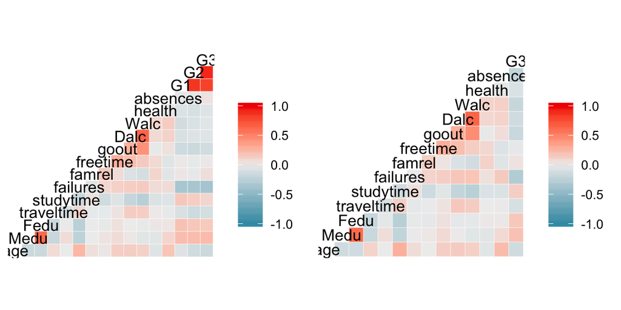

**Figure 2:** Final grade distributions before and after we drop the 0’s for analysis.

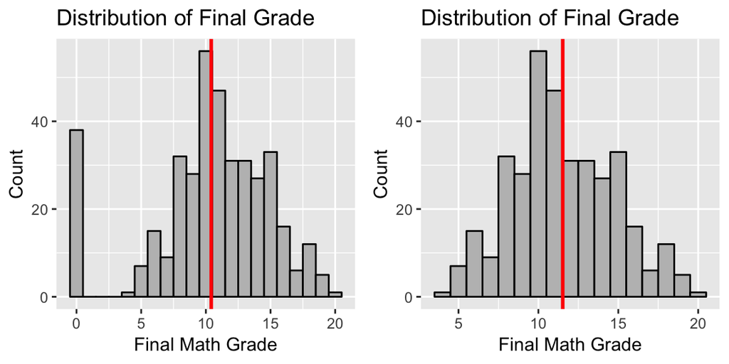

**Figure 3:** Exploratory Data Analysis plots for a select few covariates.

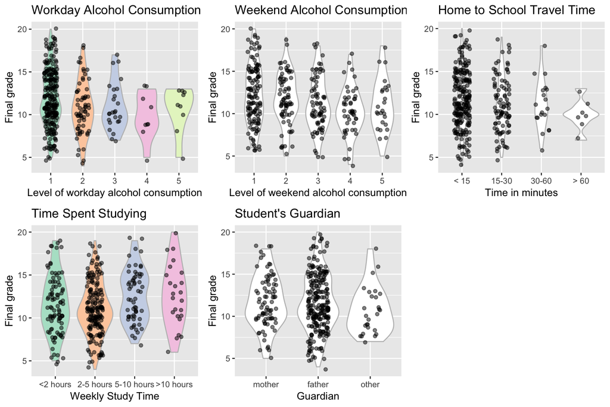

### Model Diagnostics

Based on the Anderson-Darling p-values and residual plots shown below, it appears that all 6 of the models discussed satisfy the assumptions of homogeneity (residual scatterplot), linearity (residual scatterplot), and Gaussian errors (p-value and residual histogram).

**Figure 4:** Anderson-Darling test for normailty results for each model.

| model | Anderson.Darling.p.value |
| --- | --- |
| 1 | 0.6087144 |
| 2 | 0.5029707 |
| 3 | 0.1505899 |
| 4 | 0.2578216 |
| 5 | 0.4646011 |
| 6 | 0.2294967 |

**Figure 5:** Residual analysis for each model (A-F correspond to models 1-6 respectively).

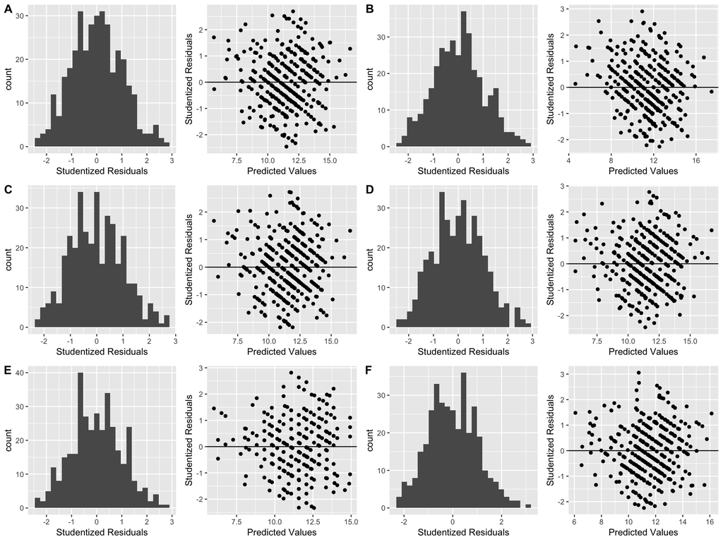